# BCG_DS_Forage_Simulation_PowerCo_Feature_Engineering

Feature Engineering for Churn Prediction

- In this phase, we executed the critical Feature Engineering and Model Preparation steps to transform the raw, cleaned data into a highly predictive dataset for our Random Forest churn model. Our primary objective was to investigate the influence of price changes on customer retention.
- The process followed a structured Remove, Expand, Combine, and Merge framework:
- Removal and Expansion: We removed redundant client columns (e.g., num_years_antig) and expanded date columns to create robust loyalty metrics, such as tenure_days.
- Combination (Price Sensitivity): We created the most impactful new features by combining client and price data:
- Price Shock: Implemented Estelle's hypothesis by calculating the difference in off-peak prices between the last and first month (offpeak_diff_dec_january_energy).
- Price Volatility: Measured the overall historical price range and mean components.
- Consumption: Created the gas_elec_ratio to categorize usage behavior.
- Preparation: Finally, we prepared the data for the Random Forest model by imputing missing values and using One-Hot Encoding to convert all categorical string variables into numerical features.
1. Import Packages

```python
# Importing all necessary libraries
import pandas as pd
import numpy as np
import matplotlib.pyplot as plt
import seaborn as sns

# Shows plots in jupyter notebook
%matplotlib inline

# Set plot style
sns.set(color_codes=True)
```

2. Load data

```python
# Fetching the files from gdrive
from google.colab import drive

# Mount Google Drive
print("Mounting Google Drive...")
drive.mount('/content/drive')

file_path = '/content/drive/MyDrive/BCG DS Forage simulation/clean_data_after_eda.csv'
df = pd.read_csv(file_path)
df.head()
```

```
Mounting Google Drive...
```

|  | id | channel_sales | cons_12m | cons_gas_12m | cons_last_month | date_activ | date_end | date_modif_prod | date_renewal | forecast_cons_12m | ... | var_6m_price_off_peak_var | var_6m_price_peak_var | var_6m_price_mid_peak_var | var_6m_price_off_peak_fix | var_6m_price_peak_fix | var_6m_price_mid_peak_fix | var_6m_price_off_peak | var_6m_price_peak | var_6m_price_mid_peak | churn |
| --- | --- | --- | --- | --- | --- | --- | --- | --- | --- | --- | --- | --- | --- | --- | --- | --- | --- | --- | --- | --- | --- |
| 0 | 24011ae4ebbe3035111d65fa7c15bc57 | foosdfpfkusacimwkcsosbicdxkicaua | 0 | 54946 | 0 | 2013-06-15 | 2016-06-15 | 2015-11-01 | 2015-06-23 | 0.00 | ... | 0.000131 | 4.100838e-05 | 9.084737e-04 | 2.086294 | 99.530517 | 44.235794 | 2.086425 | 9.953056e+01 | 4.423670e+01 | 1 |
| 1 | d29c2c54acc38ff3c0614d0a653813dd | MISSING | 4660 | 0 | 0 | 2009-08-21 | 2016-08-30 | 2009-08-21 | 2015-08-31 | 189.95 | ... | 0.000003 | 1.217891e-03 | 0.000000e+00 | 0.009482 | 0.000000 | 0.000000 | 0.009485 | 1.217891e-03 | 0.000000e+00 | 0 |
| 2 | 764c75f661154dac3a6c254cd082ea7d | foosdfpfkusacimwkcsosbicdxkicaua | 544 | 0 | 0 | 2010-04-16 | 2016-04-16 | 2010-04-16 | 2015-04-17 | 47.96 | ... | 0.000004 | 9.450150e-08 | 0.000000e+00 | 0.000000 | 0.000000 | 0.000000 | 0.000004 | 9.450150e-08 | 0.000000e+00 | 0 |
| 3 | bba03439a292a1e166f80264c16191cb | lmkebamcaaclubfxadlmueccxoimlema | 1584 | 0 | 0 | 2010-03-30 | 2016-03-30 | 2010-03-30 | 2015-03-31 | 240.04 | ... | 0.000003 | 0.000000e+00 | 0.000000e+00 | 0.000000 | 0.000000 | 0.000000 | 0.000003 | 0.000000e+00 | 0.000000e+00 | 0 |
| 4 | 149d57cf92fc41cf94415803a877cb4b | MISSING | 4425 | 0 | 526 | 2010-01-13 | 2016-03-07 | 2010-01-13 | 2015-03-09 | 445.75 | ... | 0.000011 | 2.896760e-06 | 4.860000e-10 | 0.000000 | 0.000000 | 0.000000 | 0.000011 | 2.896760e-06 | 4.860000e-10 | 0 |

5 rows × 44 columns

```python
# Convert all date columns to datetime objects
df["date_activ"] = pd.to_datetime(df["date_activ"], format='%Y-%m-%d')
df["date_end"] = pd.to_datetime(df["date_end"], format='%Y-%m-%d')
df["date_modif_prod"] = pd.to_datetime(df["date_modif_prod"], format='%Y-%m-%d')
df["date_renewal"] = pd.to_datetime(df["date_renewal"], format='%Y-%m-%d')
df.head()
df.describe()
```

|  | cons_12m | cons_gas_12m | cons_last_month | date_activ | date_end | date_modif_prod | date_renewal | forecast_cons_12m | forecast_cons_year | forecast_discount_energy | ... | var_6m_price_off_peak_var | var_6m_price_peak_var | var_6m_price_mid_peak_var | var_6m_price_off_peak_fix | var_6m_price_peak_fix | var_6m_price_mid_peak_fix | var_6m_price_off_peak | var_6m_price_peak | var_6m_price_mid_peak | churn |
| --- | --- | --- | --- | --- | --- | --- | --- | --- | --- | --- | --- | --- | --- | --- | --- | --- | --- | --- | --- | --- | --- |
| count | 1.460600e+04 | 1.460600e+04 | 14606.000000 | 14606 | 14606 | 14606 | 14606 | 14606.000000 | 14606.000000 | 14606.000000 | ... | 14606.000000 | 1.460600e+04 | 1.460600e+04 | 14606.000000 | 14606.000000 | 14606.000000 | 14606.000000 | 1.460600e+04 | 1.460600e+04 | 14606.000000 |
| mean | 1.592203e+05 | 2.809238e+04 | 16090.269752 | 2011-01-28 07:54:18.879912448 | 2016-07-27 20:48:26.422018560 | 2013-01-02 12:29:10.951663872 | 2015-07-21 06:59:00.353279488 | 1868.614880 | 1399.762906 | 0.966726 | ... | 0.000025 | 3.304264e-05 | 1.406015e-05 | 0.922810 | 1.460247 | 0.634413 | 0.922835 | 1.460280e+00 | 6.344275e-01 | 0.097152 |
| min | 0.000000e+00 | 0.000000e+00 | 0.000000 | 2003-05-09 00:00:00 | 2016-01-28 00:00:00 | 2003-05-09 00:00:00 | 2013-06-26 00:00:00 | 0.000000 | 0.000000 | 0.000000 | ... | 0.000000 | 0.000000e+00 | 0.000000e+00 | 0.000000 | 0.000000 | 0.000000 | 0.000000 | 0.000000e+00 | 0.000000e+00 | 0.000000 |
| 25% | 5.674750e+03 | 0.000000e+00 | 0.000000 | 2010-01-15 00:00:00 | 2016-04-27 06:00:00 | 2010-08-12 00:00:00 | 2015-04-17 00:00:00 | 494.995000 | 0.000000 | 0.000000 | ... | 0.000003 | 0.000000e+00 | 0.000000e+00 | 0.000000 | 0.000000 | 0.000000 | 0.000004 | 0.000000e+00 | 0.000000e+00 | 0.000000 |
| 50% | 1.411550e+04 | 0.000000e+00 | 792.500000 | 2011-03-04 00:00:00 | 2016-08-01 00:00:00 | 2013-06-19 00:00:00 | 2015-07-27 00:00:00 | 1112.875000 | 314.000000 | 0.000000 | ... | 0.000004 | 9.450150e-08 | 0.000000e+00 | 0.000000 | 0.000000 | 0.000000 | 0.000011 | 9.450150e-08 | 0.000000e+00 | 0.000000 |
| 75% | 4.076375e+04 | 0.000000e+00 | 3383.000000 | 2012-04-19 00:00:00 | 2016-10-31 00:00:00 | 2015-06-16 00:00:00 | 2015-10-29 00:00:00 | 2401.790000 | 1745.750000 | 0.000000 | ... | 0.000011 | 2.896760e-06 | 4.860000e-10 | 0.007962 | 0.000000 | 0.000000 | 0.007973 | 2.896760e-06 | 4.860000e-10 | 0.000000 |
| max | 6.207104e+06 | 4.154590e+06 | 771203.000000 | 2014-09-01 00:00:00 | 2017-06-13 00:00:00 | 2016-01-29 00:00:00 | 2016-01-28 00:00:00 | 82902.830000 | 175375.000000 | 30.000000 | ... | 0.005543 | 4.791197e-03 | 2.415288e-03 | 525.988881 | 399.471115 | 80.876029 | 525.994268 | 3.994725e+02 | 8.087765e+01 | 1.000000 |
| std | 5.734653e+05 | 1.629731e+05 | 64364.196422 | NaN | NaN | NaN | NaN | 2387.571531 | 3247.786255 | 5.108289 | ... | 0.000204 | 2.231791e-04 | 1.273170e-04 | 18.218286 | 13.760009 | 5.895346 | 18.218452 | 1.376010e+01 | 5.895470e+00 | 0.296175 |

8 rows × 40 columns

3. Feature engineering

Important feature: Difference between off-peak prices in December and preceding January

```python
# Importing price data and changing the date col in the price data to work on feature: Difference between off-peak prices in December and preceding January
# Fetching the files from gdrive
#from google.colab import drive

# Mount Google Drive
#print("Mounting Google Drive...")
#drive.mount('/content/drive')

file_path_price = '/content/drive/MyDrive/BCG DS Forage simulation/BCG-Forage_PowerCo_Price Data.csv'
price_df = pd.read_csv(file_path_price)
price_df["price_date"] = pd.to_datetime(price_df["price_date"], format='%Y-%m-%d')
price_df.info()

price_df.head()
```

```
<class 'pandas.core.frame.DataFrame'>
RangeIndex: 193002 entries, 0 to 193001
Data columns (total 8 columns):
 #   Column              Non-Null Count   Dtype
---  ------              --------------   -----
 0   id                  193002 non-null  object
 1   price_date          193002 non-null  datetime64[ns]
 2   price_off_peak_var  193002 non-null  float64
 3   price_peak_var      193002 non-null  float64
 4   price_mid_peak_var  193002 non-null  float64
 5   price_off_peak_fix  193002 non-null  float64
 6   price_peak_fix      193002 non-null  float64
 7   price_mid_peak_fix  193002 non-null  float64
dtypes: datetime64[ns](1), float64(6), object(1)
memory usage: 11.8+ MB
```

|  | id | price_date | price_off_peak_var | price_peak_var | price_mid_peak_var | price_off_peak_fix | price_peak_fix | price_mid_peak_fix |
| --- | --- | --- | --- | --- | --- | --- | --- | --- |
| 0 | 038af19179925da21a25619c5a24b745 | 2015-01-01 | 0.151367 | 0.0 | 0.0 | 44.266931 | 0.0 | 0.0 |
| 1 | 038af19179925da21a25619c5a24b745 | 2015-02-01 | 0.151367 | 0.0 | 0.0 | 44.266931 | 0.0 | 0.0 |
| 2 | 038af19179925da21a25619c5a24b745 | 2015-03-01 | 0.151367 | 0.0 | 0.0 | 44.266931 | 0.0 | 0.0 |
| 3 | 038af19179925da21a25619c5a24b745 | 2015-04-01 | 0.149626 | 0.0 | 0.0 | 44.266931 | 0.0 | 0.0 |
| 4 | 038af19179925da21a25619c5a24b745 | 2015-05-01 | 0.149626 | 0.0 | 0.0 | 44.266931 | 0.0 | 0.0 |

```python
# Boolean Transform and Immediate Cleanup
# Manually transform the 'has_gas' boolean/categorical column to a binary flag (1/0)
df['has_gas'] = df['has_gas'].replace(['t', 'f'], [1, 0])
churn_by_gas = df.groupby(['has_gas']).agg({'churn': 'mean'})
print(churn_by_gas)

# Remove Columns (De-Duplication & Irrelevance)
columns_to_drop = ['num_years_antig', 'margin_net_pow_ele']
df.drop(columns=columns_to_drop, inplace=True, errors='ignore')
print("✅ Redundant columns dropped.")

# Expand Columns (Loyalty Features)
# Create precise loyalty and date features
study_end_date = df['date_end'].max()
df['tenure_days'] = (
    study_end_date - df['date_activ']
).dt.days
df['activ_month'] = df['date_activ'].dt.month

# Drop the raw date columns
date_cols_to_drop = ['date_activ', 'date_end', 'date_modif_prod', 'date_renewal']
df.drop(columns=date_cols_to_drop, inplace=True, errors='ignore')

print("✅ Loyalty features (tenure_days, activ_month) created.")

df.info()
```

```
            churn
has_gas
0        0.100544
1        0.081856
✅ Redundant columns dropped.
✅ Loyalty features (tenure_days, activ_month) created.
<class 'pandas.core.frame.DataFrame'>
RangeIndex: 14606 entries, 0 to 14605
Data columns (total 40 columns):
 #   Column                          Non-Null Count  Dtype
---  ------                          --------------  -----
 0   id                              14606 non-null  object
 1   channel_sales                   14606 non-null  object
 2   cons_12m                        14606 non-null  int64
 3   cons_gas_12m                    14606 non-null  int64
```

[output cut: 38 more lines]

3.1. Feature Engineering: Price Shock Creation

- This following block directly addresses the core business hypothesis: Does a recent price change cause churn?
- It calculates the difference between the latest price (Dec) and the earliest price (Jan) for every customer.

New Features Identified:

1. offpeak_diff_dec_january_energy: This feature is the numerical measure of the recent shock in the variable energy price (what clients actually pay per kWh).
2. offpeak_diff_dec_january_power: This feature measures the change in the fixed component (standing charge). It's crucial because clients often notice fixed charges more than small variable rate changes.

```python
# Group off-peak prices by companies and month
monthly_price_by_id = price_df.groupby(['id', 'price_date']).agg({'price_off_peak_var': 'mean', 'price_off_peak_fix': 'mean'}).reset_index()

# Get january and december prices
jan_prices = monthly_price_by_id.groupby('id').first().reset_index()
dec_prices = monthly_price_by_id.groupby('id').last().reset_index()

# Calculate the difference
diff = pd.merge(dec_prices.rename(columns={'price_off_peak_var': 'dec_1', 'price_off_peak_fix': 'dec_2'}), jan_prices.drop(columns='price_date'), on='id')
diff['offpeak_diff_dec_january_energy'] = diff['dec_1'] - diff['price_off_peak_var']
diff['offpeak_diff_dec_january_power'] = diff['dec_2'] - diff['price_off_peak_fix']
diff = diff[['id', 'offpeak_diff_dec_january_energy','offpeak_diff_dec_january_power']]
diff.head()
```

|  | id | offpeak_diff_dec_january_energy | offpeak_diff_dec_january_power |
| --- | --- | --- | --- |
| 0 | 0002203ffbb812588b632b9e628cc38d | -0.006192 | 0.162916 |
| 1 | 0004351ebdd665e6ee664792efc4fd13 | -0.004104 | 0.177779 |
| 2 | 0010bcc39e42b3c2131ed2ce55246e3c | 0.050443 | 1.500000 |
| 3 | 0010ee3855fdea87602a5b7aba8e42de | -0.010018 | 0.162916 |
| 4 | 00114d74e963e47177db89bc70108537 | -0.003994 | -0.000001 |

3.2. Feature Engineering: Integration and Consumption Habit

- The following code completes the integration of price features and creates a new, insightful feature based on customer usage.
1. Merging Price Shock Features:

   The line df = pd.merge(df, diff, on='id', how='left') is essential for incorporating the new price signals. It uses the unique id column to combine the diff DataFrame (containing the price shock features) with the main client DataFrame, df. The main DataFrame, df, is instantly enriched with the two columns: offpeak_diff_dec_january_energy and offpeak_diff_dec_january_power.
2. Consumption Habit Feature: gas_elec_ratio:

```python
# Merge the new price difference features into the main client dataframe (df)
df = pd.merge(df, diff, on='id', how='left')

# Consumption Habit Feature (Gas vs. Electricity Ratio)
print("\nCreating Consumption Habit Feature:")
# Creates a ratio to identify customers' primary consumption focus (Gas vs. Electricity)
epsilon = 1e-6 # To avoid division by zero
df['gas_elec_ratio'] = (
    df['cons_gas_12m'] / (df['cons_12m'] + epsilon)
)

print("✅ Price Difference Features Merged.")
print("✅ Gas/Electricity Ratio Feature Added.")

df.head()
```

```
Creating Consumption Habit Feature:
✅ Price Difference Features Merged.
✅ Gas/Electricity Ratio Feature Added.
```

|  | id | channel_sales | cons_12m | cons_gas_12m | cons_last_month | forecast_cons_12m | forecast_cons_year | forecast_discount_energy | forecast_meter_rent_12m | forecast_price_energy_off_peak | ... | var_6m_price_mid_peak_fix | var_6m_price_off_peak | var_6m_price_peak | var_6m_price_mid_peak | churn | tenure_days | activ_month | offpeak_diff_dec_january_energy | offpeak_diff_dec_january_power | gas_elec_ratio |
| --- | --- | --- | --- | --- | --- | --- | --- | --- | --- | --- | --- | --- | --- | --- | --- | --- | --- | --- | --- | --- | --- |
| 0 | 24011ae4ebbe3035111d65fa7c15bc57 | foosdfpfkusacimwkcsosbicdxkicaua | 0 | 54946 | 0 | 0.00 | 0 | 0.0 | 1.78 | 0.114481 | ... | 44.235794 | 2.086425 | 9.953056e+01 | 4.423670e+01 | 1 | 1459 | 6 | 0.020057 | 3.700961 | 5.494600e+10 |
| 1 | d29c2c54acc38ff3c0614d0a653813dd | MISSING | 4660 | 0 | 0 | 189.95 | 0 | 0.0 | 16.27 | 0.145711 | ... | 0.000000 | 0.009485 | 1.217891e-03 | 0.000000e+00 | 0 | 2853 | 8 | -0.003767 | 0.177779 | 0.000000e+00 |
| 2 | 764c75f661154dac3a6c254cd082ea7d | foosdfpfkusacimwkcsosbicdxkicaua | 544 | 0 | 0 | 47.96 | 0 | 0.0 | 38.72 | 0.165794 | ... | 0.000000 | 0.000004 | 9.450150e-08 | 0.000000e+00 | 0 | 2615 | 4 | -0.004670 | 0.177779 | 0.000000e+00 |
| 3 | bba03439a292a1e166f80264c16191cb | lmkebamcaaclubfxadlmueccxoimlema | 1584 | 0 | 0 | 240.04 | 0 | 0.0 | 19.83 | 0.146694 | ... | 0.000000 | 0.000003 | 0.000000e+00 | 0.000000e+00 | 0 | 2632 | 3 | -0.004547 | 0.177779 | 0.000000e+00 |
| 4 | 149d57cf92fc41cf94415803a877cb4b | MISSING | 4425 | 0 | 526 | 445.75 | 526 | 0.0 | 131.73 | 0.116900 | ... | 0.000000 | 0.000011 | 2.896760e-06 | 4.860000e-10 | 0 | 2708 | 1 | -0.006192 | 0.162916 | 0.000000e+00 |

5 rows × 43 columns

3.3. Feature Engineering: Price Volatility Feature

- This block identifies and adds features that measure a customer's long-term exposure to price changes—known as Price Volatility.
- Features Identified:
1. offpeak_price_range_var: This is the volatility feature. It measures the maximum historical spread (Max Price - Min Price) a client has experienced. Clients who've seen high volatility might be more likely to churn.
2. price_fix_mean: Captures the average historical fixed price, providing a baseline for the client's standing charge exposure.
3. price_var_mean: Captures the average historical variable price, establishing the typical energy cost baseline for the client.

```python
print("\nCreating Historical Price Volatility Features")

# Group by client ID and aggregate the entire price history
price_agg_full = price_df.groupby(['id']).agg(
    # Max price fluctuation for off-peak variable component
    offpeak_price_range_var=('price_off_peak_var', lambda x: x.max() - x.min()),
    # Historical mean for fixed and variable price components
    price_fix_mean=('price_off_peak_fix', 'mean'),
    price_var_mean=('price_off_peak_var', 'mean')
).reset_index()

# Merge these volatility features into the main client dataframe
df = pd.merge(
    df,
    price_agg_full,
    on='id',
    how='left'
)

print("✅ Historical Volatility Features Added.")

df.head()
```

```
Creating Historical Price Volatility Features
✅ Historical Volatility Features Added.
```

|  | id | channel_sales | cons_12m | cons_gas_12m | cons_last_month | forecast_cons_12m | forecast_cons_year | forecast_discount_energy | forecast_meter_rent_12m | forecast_price_energy_off_peak | ... | var_6m_price_mid_peak | churn | tenure_days | activ_month | offpeak_diff_dec_january_energy | offpeak_diff_dec_january_power | gas_elec_ratio | offpeak_price_range_var | price_fix_mean | price_var_mean |
| --- | --- | --- | --- | --- | --- | --- | --- | --- | --- | --- | --- | --- | --- | --- | --- | --- | --- | --- | --- | --- | --- |
| 0 | 24011ae4ebbe3035111d65fa7c15bc57 | foosdfpfkusacimwkcsosbicdxkicaua | 0 | 54946 | 0 | 0.00 | 0 | 0.0 | 1.78 | 0.114481 | ... | 4.423670e+01 | 1 | 1459 | 6 | 0.020057 | 3.700961 | 5.494600e+10 | 0.028554 | 40.942265 | 0.124787 |
| 1 | d29c2c54acc38ff3c0614d0a653813dd | MISSING | 4660 | 0 | 0 | 189.95 | 0 | 0.0 | 16.27 | 0.145711 | ... | 0.000000e+00 | 0 | 2853 | 8 | -0.003767 | 0.177779 | 0.000000e+00 | 0.005334 | 44.311375 | 0.149609 |
| 2 | 764c75f661154dac3a6c254cd082ea7d | foosdfpfkusacimwkcsosbicdxkicaua | 544 | 0 | 0 | 47.96 | 0 | 0.0 | 38.72 | 0.165794 | ... | 0.000000e+00 | 0 | 2615 | 4 | -0.004670 | 0.177779 | 0.000000e+00 | 0.004670 | 44.385450 | 0.170512 |
| 3 | bba03439a292a1e166f80264c16191cb | lmkebamcaaclubfxadlmueccxoimlema | 1584 | 0 | 0 | 240.04 | 0 | 0.0 | 19.83 | 0.146694 | ... | 0.000000e+00 | 0 | 2632 | 3 | -0.004547 | 0.177779 | 0.000000e+00 | 0.004547 | 44.400265 | 0.151210 |
| 4 | 149d57cf92fc41cf94415803a877cb4b | MISSING | 4425 | 0 | 526 | 445.75 | 526 | 0.0 | 131.73 | 0.116900 | ... | 4.860000e-10 | 0 | 2708 | 1 | -0.006192 | 0.162916 | 0.000000e+00 | 0.008161 | 40.688156 | 0.124174 |

5 rows × 46 columns

- Transforming numerical data: The reason why we need to treat skewness is because some predictive models have inherent assumptions about the distribution of the features. Such models are called parametric models, and they typically assume that all variables are both independent and normally distributed.

Skewness isn't always a bad thing, but as a rule of thumb it is good practice to treat highly skewed variables to make them more normally distributed. This can also increase the speed at which predictive models are able to converge to the best solution.

There are many ways that you can treat skewed variables. You can apply transformations such as:

Square root Cubic root Logarithm to a continuous numeric column and you will notice the distribution changes. For this use case we will use the 'Logarithm' transformation for the positively skewed features.

Note: We cannot apply log to a value of 0, so we will add a constant of 1 to all the values

We will check the distributions before and after transformation, and expect the standard deviations to decrease.

```python
skewed_cols = [
    'cons_12m',
    'cons_gas_12m',
    'cons_last_month',
    'forecast_cons_12m',
    'forecast_cons_year',
    'forecast_discount_energy',
    'forecast_meter_rent_12m',
    'forecast_price_energy_off_peak',
    'forecast_price_energy_peak',
    'forecast_price_pow_off_peak',
    'tenure_days'
]

print("Before log transform:")
print(df[skewed_cols].describe())

df[skewed_cols] = np.log10(df[skewed_cols] + 1)

print("After log transform:")
print(df[skewed_cols].describe())
```

```
Before log transform:
           cons_12m  cons_gas_12m  cons_last_month  forecast_cons_12m  \
count  1.460600e+04  1.460600e+04     14606.000000       14606.000000
mean   1.592203e+05  2.809238e+04     16090.269752        1868.614880
std    5.734653e+05  1.629731e+05     64364.196422        2387.571531
min    0.000000e+00  0.000000e+00         0.000000           0.000000
25%    5.674750e+03  0.000000e+00         0.000000         494.995000
50%    1.411550e+04  0.000000e+00       792.500000        1112.875000
75%    4.076375e+04  0.000000e+00      3383.000000        2401.790000
max    6.207104e+06  4.154590e+06    771203.000000       82902.830000

       forecast_cons_year  forecast_discount_energy  forecast_meter_rent_12m  \
count        14606.000000              14606.000000             14606.000000
mean          1399.762906                  0.966726                63.086871
std           3247.786255                  5.108289                66.165783
min              0.000000                  0.000000                 0.000000
25%              0.000000                  0.000000                16.180000
50%            314.000000                  0.000000                18.795000
75%           1745.750000                  0.000000               131.030000
max         175375.000000                 30.000000               599.310000

       forecast_price_energy_off_peak  forecast_price_energy_peak  \
count                    14606.000000                14606.000000
mean                         0.137283                    0.050491
std                          0.024623                    0.049037
min                          0.000000                    0.000000
25%                          0.116340                    0.000000
50%                          0.143166                    0.084138
75%                          0.146348                    0.098837
max                          0.273963                    0.195975

       forecast_price_pow_off_peak   tenure_days
count                 14606.000000  14606.000000
mean                     43.130056   2327.670615
std                       4.485988    589.317924
min                       0.000000   1016.000000
25%                      40.606701   1881.000000
50%                      44.311378   2293.000000
75%                      44.311378   2706.000000
max                      59.266378   5149.000000
```

[output cut: 25 more lines]

```
min                          0.000000                    0.000000
25%                          0.047796                    0.000000
50%                          0.058109                    0.035085
75%                          0.059316                    0.040933
max                          0.105157                    0.077722

       forecast_price_pow_off_peak   tenure_days
count                 14606.000000  14606.000000
mean                      1.636058      3.354556
std                       0.134237      0.102754
min                       0.000000      3.007321
25%                       1.619163      3.274620
50%                       1.656207      3.360593
75%                       1.656207      3.432488
max                       1.780075      3.711807
```

Now we can see that for the majority of the features, the standard deviation is much lower after transformation. This is a good thing as it shows that these features are more stable and predictable now.

Let's plot a few of these distributions too.

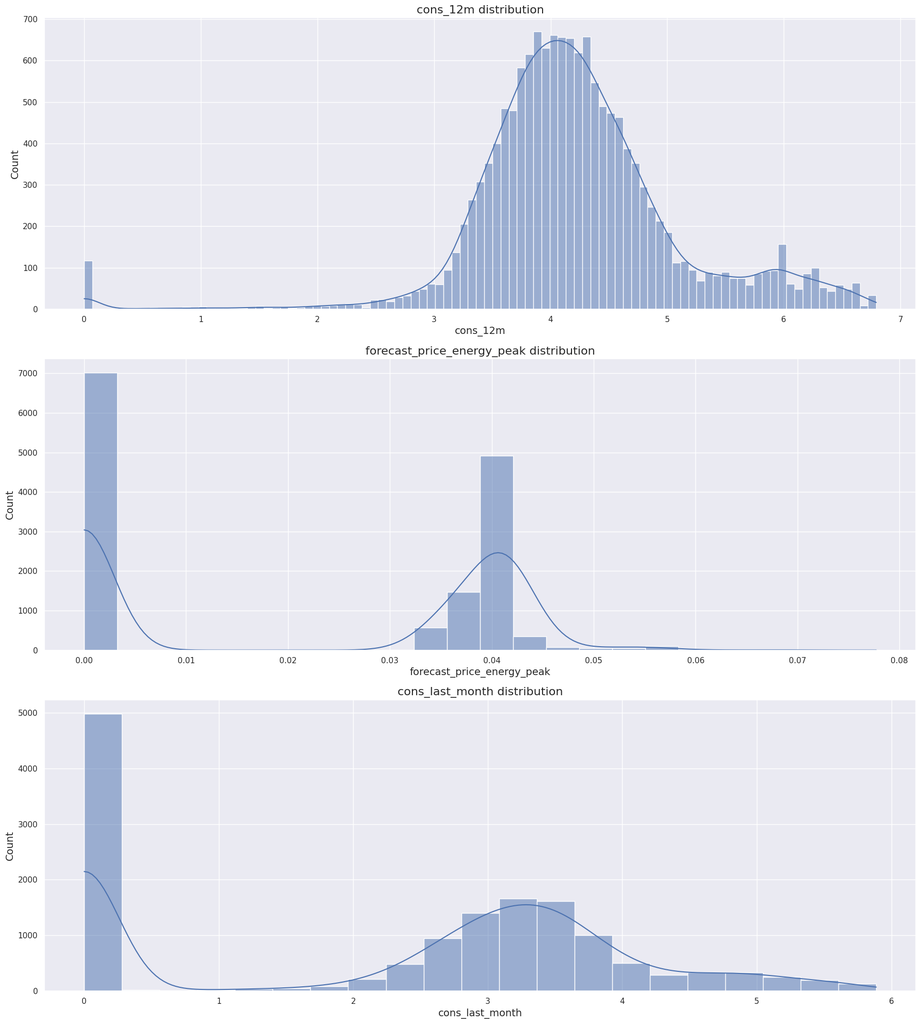

```python
cols = ["cons_12m", "forecast_price_energy_peak", "cons_last_month"]

# Set up subplots
fig, axs = plt.subplots(nrows=len(cols), figsize=(18, 20))

# Loop through each column and plot
for ax, col in zip(axs, cols):
    sns.histplot(df[col].dropna(), kde=True, ax=ax)
    ax.set_title(f"{col} distribution", fontsize=16)
    ax.set_xlabel(col, fontsize=14)
    ax.set_ylabel("Count", fontsize=14)

plt.tight_layout()
plt.show()
```

```python
df.head()
```

|  | id | channel_sales | cons_12m | cons_gas_12m | cons_last_month | forecast_cons_12m | forecast_cons_year | forecast_discount_energy | forecast_meter_rent_12m | forecast_price_energy_off_peak | ... | var_6m_price_mid_peak | churn | tenure_days | activ_month | offpeak_diff_dec_january_energy | offpeak_diff_dec_january_power | gas_elec_ratio | offpeak_price_range_var | price_fix_mean | price_var_mean |
| --- | --- | --- | --- | --- | --- | --- | --- | --- | --- | --- | --- | --- | --- | --- | --- | --- | --- | --- | --- | --- | --- |
| 0 | 24011ae4ebbe3035111d65fa7c15bc57 | foosdfpfkusacimwkcsosbicdxkicaua | 0.000000 | 4.739944 | 0.000000 | 0.000000 | 0.000000 | 0.0 | 0.444045 | 0.047073 | ... | 4.423670e+01 | 1 | 3.164353 | 6 | 0.020057 | 3.700961 | 5.494600e+10 | 0.028554 | 40.942265 | 0.124787 |
| 1 | d29c2c54acc38ff3c0614d0a653813dd | MISSING | 3.668479 | 0.000000 | 0.000000 | 2.280920 | 0.000000 | 0.0 | 1.237292 | 0.059075 | ... | 0.000000e+00 | 0 | 3.455454 | 8 | -0.003767 | 0.177779 | 0.000000e+00 | 0.005334 | 44.311375 | 0.149609 |
| 2 | 764c75f661154dac3a6c254cd082ea7d | foosdfpfkusacimwkcsosbicdxkicaua | 2.736397 | 0.000000 | 0.000000 | 1.689841 | 0.000000 | 0.0 | 1.599009 | 0.066622 | ... | 0.000000e+00 | 0 | 3.417638 | 4 | -0.004670 | 0.177779 | 0.000000e+00 | 0.004670 | 44.385450 | 0.170512 |
| 3 | bba03439a292a1e166f80264c16191cb | lmkebamcaaclubfxadlmueccxoimlema | 3.200029 | 0.000000 | 0.000000 | 2.382089 | 0.000000 | 0.0 | 1.318689 | 0.059448 | ... | 0.000000e+00 | 0 | 3.420451 | 3 | -0.004547 | 0.177779 | 0.000000e+00 | 0.004547 | 44.400265 | 0.151210 |
| 4 | 149d57cf92fc41cf94415803a877cb4b | MISSING | 3.646011 | 0.000000 | 2.721811 | 2.650065 | 2.721811 | 0.0 | 2.122969 | 0.048014 | ... | 4.860000e-10 | 0 | 3.432809 | 1 | -0.006192 | 0.162916 | 0.000000e+00 | 0.008161 | 40.688156 | 0.124174 |

5 rows × 46 columns

- Correlations

Creating new featuers requires trial and error and requires iteration. To determine if we are on the right track, we can check the correlation between our new features with our target variable of interest. We also want to check if features are highly correlated with each other (and leave only one in the model), since predictive models work best when the features are uncorrelated.

```python
# 1. Drop the non-numeric 'id' column
# This is required because 'id' is a string unique identifier.
df_final = df.drop(columns=['id'])

# 2. Convert ALL remaining 'object' (string) columns to numeric features (One-Hot Encoding)
# This includes 'activity_new', 'channel_sales', and 'origin_up'.
# Note: The model answer uses drop_first=True for encoding, which is good practice to avoid multicollinearity.
df_final = pd.get_dummies(
    df_final,
    columns=df_final.select_dtypes(include=['object']).columns,
    drop_first=True
)

# 3. Calculate the correlation matrix on the fully numeric DataFrame
correlation = df_final.corr()

# 4. Print the top 10 features most correlated with 'churn' (Target)
print("\n--- Top 10 Features Correlated with CHURN ---")
print(correlation['churn'].sort_values(key=abs, ascending=False).head(11))
```

```
--- Top 10 Features Correlated with CHURN ---
churn                                             1.000000
margin_gross_pow_ele                              0.095725
origin_up_lxidpiddsbxsbosboudacockeimpuepw        0.094131
tenure_days                                      -0.081977
origin_up_kamkkxfxxuwbdslkwifmmcsiusiuosws       -0.080766
channel_sales_foosdfpfkusacimwkcsosbicdxkicaua    0.075964
channel_sales_lmkebamcaaclubfxadlmueccxoimlema   -0.052946
net_margin                                        0.041135
forecast_meter_rent_12m                           0.038964
offpeak_price_range_var                           0.033062
pow_max                                           0.030362
Name: churn, dtype: float64
```

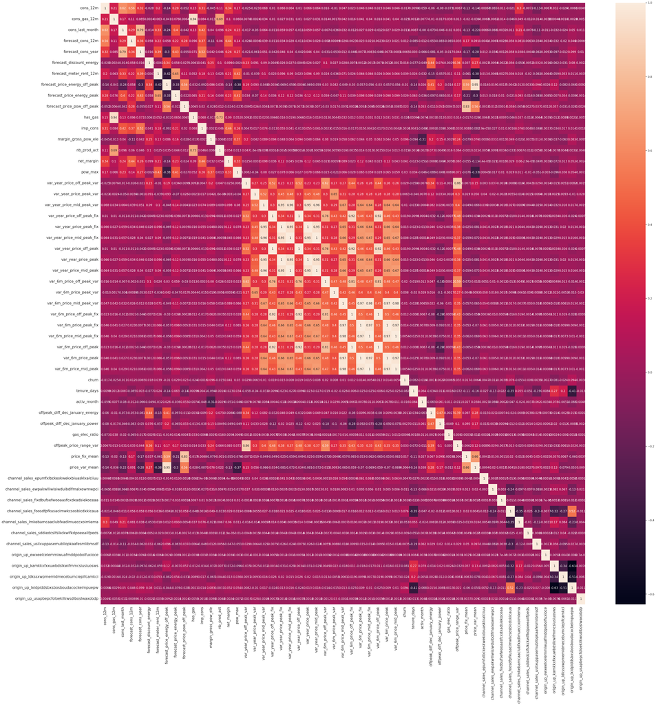

```python
# Plot correlation
plt.figure(figsize=(45, 45))
sns.heatmap(
    correlation,
    xticklabels=correlation.columns.values,
    yticklabels=correlation.columns.values,
    annot=True,
    annot_kws={'size': 12}
)
# Axis ticks size
plt.xticks(fontsize=15)
plt.yticks(fontsize=15)
plt.show()
```

4. Model Preparation
- This final block completes the Model Preparation phase, ensuring the engineered features are in a format the Random Forest model can use.
- Steps:
1. Imputation: Fills any missing values (NaNs) in the new price features (caused by the merge) with 0. Ensures the model doesn't crash on null data; a value of 0 implies "no price change" or "no volatility," which is a valid signal.
2. ID Column Drop: Removes the unique, non-predictive id column. The model can't use unique identifiers; it must be removed before training.
3. One-Hot Encoding: Converts all remaining text/string categorical columns (like channel_sales) into numerical dummy variables (0s and 1s). The Random Forest model requires purely numerical input to run.
4. Final Split: Separates the final feature set (X) from the target variable (y, the churn column). The data is structurally ready for the final step: Model Training.

```python
print("\nFinal Preparation for Random Forest Model")

# 1. Imputation (Handling Missing Values)
# Fill NaNs in the new price features (introduced by the merges) with 0.
impute_cols = [
    'offpeak_diff_dec_january_energy',
    'offpeak_diff_dec_january_power',
    'offpeak_price_range_var',
    'price_fix_mean',
    'price_var_mean'
]
for col in impute_cols:
    df[col].fillna(0, inplace=True)

print("✅ NaNs in Price Features Imputed with 0.")

# 2. Categorical Encoding and Final Cleanup
# Drop the final 'id' column before encoding/modeling
df.drop(columns=['id'], inplace=True)

# Convert all remaining 'object' columns (text) into numerical dummy variables.
# The 'drop_first=True' is good practice to prevent multicollinearity.
df_final = pd.get_dummies(df, columns=df.select_dtypes(include=['object']).columns, drop_first=True)

print("✅ Categorical Features One-Hot Encoded.")

# 3. Calculate Correlation (Optional, but now works)
correlation = df_final.corr()
print("\n--- Correlation Matrix Sample ---")
print(correlation.head().iloc[:, :5]) # Print a small sample for readability

# 4. Separate features (X) from the target (y)
X = df_final.drop(columns=['churn'])
y = df_final['churn']

print(f"\nFinal feature count for modeling (X): {X.shape[1]}")
print("Data is now fully engineered and ready for training the Random Forest classifier.")
```

[output not shown]